# Topic & Sentimental Analysis in Inaugural Address

This RNotebook is written by Yue Gao.  
In this project, I analyzed the frequencies of each president mentioning some main topics ( economy, employment, education, national security, geopolitics, production ) and investigated the cooccurence of these topics. I also conducted a sentimental analysis for each president using Wordstat sentimental dictionary. Finally, I used these dimensional vectors *( frequencies of 6 topics and different emotions )* of presidents in the k-mean clustering and got an interesting result. I have also conducted a similarity analysis on Trump’s speech & Hillary’s speech versus some recent presidents.

## Step 1: Install libraries and import data

```r
packages.used=c("quanteda","igraph","devtools", "factoextra","RColorBrewer")

# check packages that need to be installed.
packages.needed=setdiff(packages.used,intersect(installed.packages()[,1],packages.used))

# install additional packages
if(length(packages.needed)>0){
  install.packages(packages.needed, dependencies = TRUE,
                   repos='http://cran.us.r-project.org')
}

#for install a library from GitHub
library(devtools)

#readtext is not listed in CRAN yet
if (!is.element("readtext",installed.packages()[,1])){
    devtools::install_github("kbenoit/readtext")
  }

#load the libraries
library(readtext)
library(igraph)
library(quanteda)
library(factoextra)
library(RColorBrewer)

#the author of quanteda made a database of all the inaugural address under the char"data_char_inaugural", but the data in the package is not updated yet. He personally uploaded a new version including Trump's speech on his GitHub, so here I downloaded the new data and load it into the workspace

load("~/GitHub/Spr2017-Proj1-ciellagrange/data/data_char_inaugural.RData")

# build the corpus for all presidential speech
str(data_char_inaugural)
```

```
##  Named chr [1:58] "Fellow-Citizens of the Senate and of the House of Representatives:\n\nAmong the vicissitudes incident to life no event could ha"| __truncated__ ...
##  - attr(*, "names")= chr [1:58] "1789-Washington" "1793-Washington" "1797-Adams" "1801-Jefferson" ...
```

```r
presi<-corpus(data_char_inaugural)

#add some features to the corpus
docvars(presi, "Year") <- as.integer(substring(names(data_char_inaugural), 1, 4))
docvars(presi, "President") <- substring(names(data_char_inaugural), 6)

#load the Hillary nomination speech for comparison
hillary<-corpus(readtext("~/GitHub/Spr2017-Proj1-ciellagrange/data/2016-Hillary.txt"))
docnames(hillary)<-"2016-Hillary"
docvars(hillary,"Year")<-2016
docvars(hillary,"President")<-"Hillary"

#make a complete corpus including Hillary
myCorpus <- presi+hillary

summary(corpus_subset(myCorpus,Year>1980))
```

```
## Corpus consisting of 11 documents.
##
##          Text Types Tokens Sentences Year President
##   1981-Reagan   904   2798       128 1981    Reagan
##   1985-Reagan   925   2935       123 1985    Reagan
##     1989-Bush   795   2683       141 1989      Bush
##  1993-Clinton   644   1837        81 1993   Clinton
##  1997-Clinton   773   2451       111 1997   Clinton
##     2001-Bush   622   1810        97 2001      Bush
##     2005-Bush   772   2325       100 2005      Bush
##    2009-Obama   939   2729       110 2009     Obama
##    2013-Obama   814   2335        88 2013     Obama
##    2017-Trump   582   1662        88 2017     Trump
##  2016-Hillary  1542   5860       346 2016   Hillary
##
## Source:  Combination of corpuses presi and hillary
## Created: Fri Feb  3 14:09:12 2017
## Notes:
```

Now we have built a library consists of all the presidents’ inaugural addresses and we have also included Hillary Clinton’s nomination speech for further comparison.

## Step 2: Generate wordcloud

We first take a look at the general wordcloud of all the presidents’ speech.

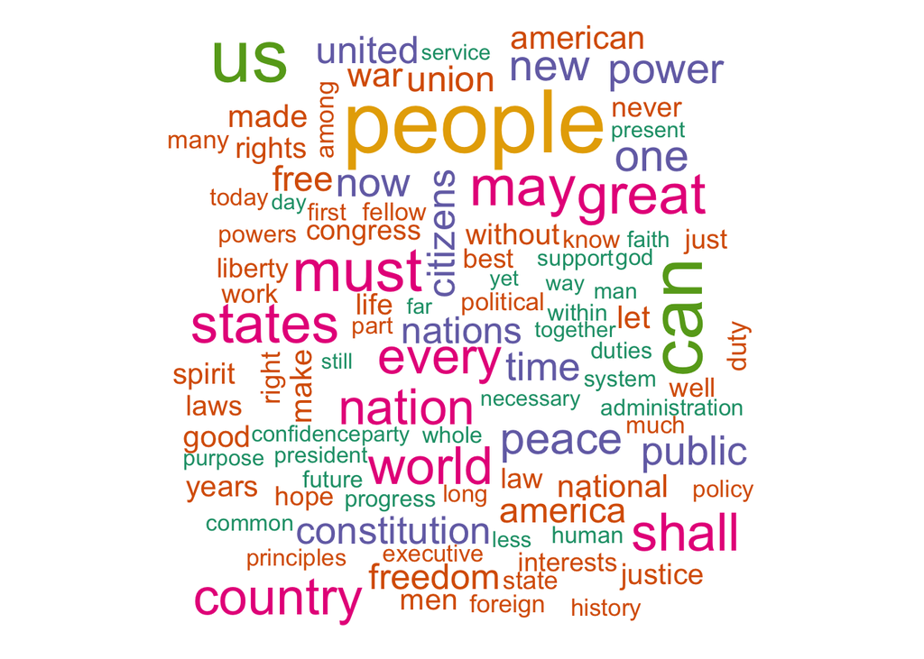

```r
mydfm <- dfm(presi,remove = c("will", stopwords("english")),
             removePunct = TRUE)
textplot_wordcloud(mydfm,max.words = 100,colors = brewer.pal(6, "Dark2"), scale = c(4, .5))
```

It doesn’t give us too much information about their plans because every president would say the same words on their inaugural speeches. So we use the TF-IDF method to control the weights of those common words and take a further look.

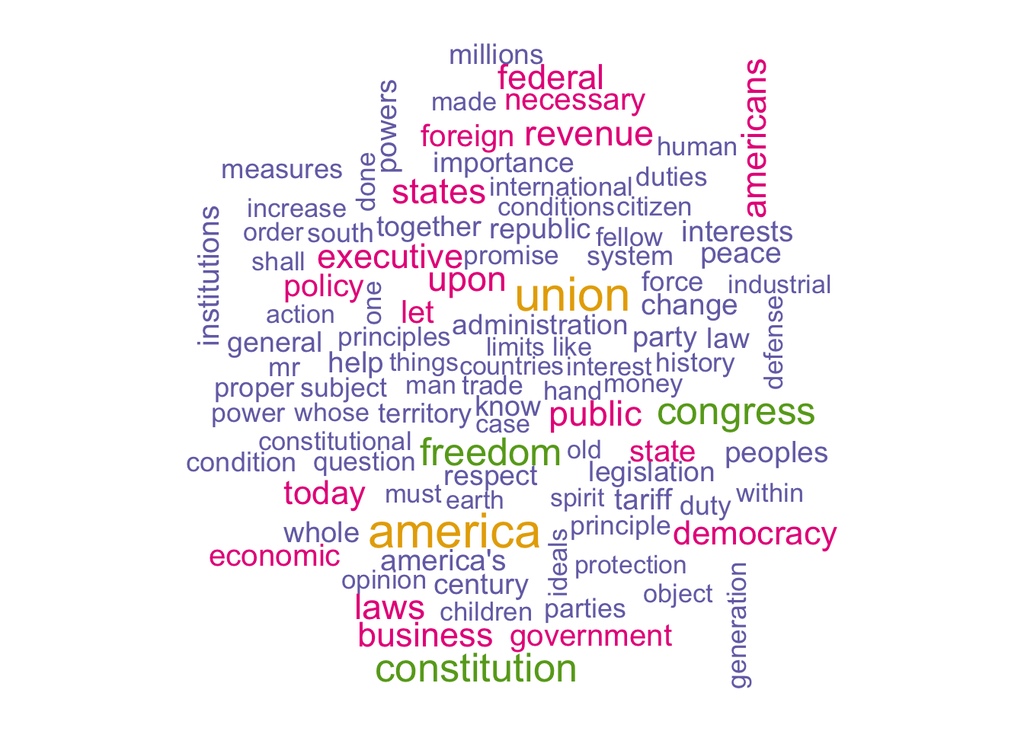

```r
mydfm1<-tfidf(mydfm)
textplot_wordcloud(mydfm1,max.words = 100,colors = brewer.pal(6, "Dark2"), scale = c(2, .5))
```

Now the results are more informative.

## Step 3: Import and define dictionary

I have tried using the topic models for investigating the popular topics in the speeches, but the result is too general–most of them are about the nation and American spirits. Thus I tried to define my own dictionary using the most common 1000 words extracted from president speeches after 1920.

```r
mydfm2 <- dfm(corpus_subset(presi,Year>1920),remove = c("will", stopwords("english")),
             removePunct = TRUE,stem=TRUE)
x<-topfeatures(mydfm2, 1000)
write.csv(x,file="~/GitHub/Spr2017-Proj1-ciellagrange/lib/dic.csv")
```

Here I have manually picked 6 topics (economy, employment, national security, production, geopolitics, education) that I’m interested in and also some popular words under these topics. These popular words are picked from the 1000 common words.

I made a self-defined dictionary as follows:

```r
economy = c("business", "grow*","pay","poverty","price","finance","bank*", "economy","economics","debt","capital","enterprise","expenditure","income","tax*","tariff","market")
employment=c("jobs","work*","employ*","unemploy*","labor")
security=c("crime","safe*","danger","military","war","weapon","violence","army","navy","defend","terroris*", "threat*","attack")
production=c("build","factory","housing","land","industry","manufacture","property","infrastructure")
geopolitics=c("friend*","enemy","hostile","abroad","foreign","domestic","alliance","europe","immigrat*")
education=c("educat*","school","student")

d<-list(economy=economy,employment=employment,security=security,production=production,geopolitics=geopolitics,education=education)
myDict <- dictionary(d)
```

Also, for sentimental analysis, I have downloaded a widely used dictionary by Loughran & McDonald from https://provalisresearch.com/products/content-analysis-software/wordstat-dictionary/ .

```r
#load a sentiment dictionary by Loughran & McDonald used in wordstat
wordstat<-dictionary(file="~/GitHub/Spr2017-Proj1-ciellagrange/lib/Loughran & McDonald 2014.cat",format="wordstat")
```

## Step 4: Conduct data analysis by topics and sentiment

### Step 4.1: Topic analysis

Here we summarise the frequencies of presidents mentioning those 6 topics in their speeches.

```r
#conduct the topic data analysis
bycat<-dfm(corpus_subset(presi,Year>1920), dictionary = myDict,valuetype = "glob")
bycatlist<-data.frame(bycat)
print(bycatlist)
```

```
##                 economy employment security production geopolitics
## 1921-Harding         14          4       20          3           3
## 1925-Coolidge        27          6       10          9           9
## 1929-Hoover          18          5        8          3           6
## 1933-Roosevelt       10          5        7          4           2
## 1937-Roosevelt        2          3        2          3           0
## 1941-Roosevelt        5          0        0          3           0
## 1945-Roosevelt        0          2        2          2           2
## 1949-Truman          10         10       10          2           3
## 1953-Eisenhower       4          9       14          4           8
## 1957-Eisenhower       9          4        6          5           6
## 1961-Kennedy          5          2        5          1           6
## 1965-Johnson          4          5        1          6           4
## 1969-Nixon            3          1        5          4           3
## 1973-Nixon            0          4        6          4          10
## 1977-Carter           1          2        3          1           3
## 1981-Reagan          20         11        7          4           1
## 1985-Reagan          21         10       10          3           5
## 1989-Bush             3         10        6          1          12
## 1993-Clinton          6          8        5          1           7
## 1997-Clinton          5          8        4         14           1
## 2001-Bush             6          5        5          2           1
## 2005-Bush             1          6        5          2           2
## 2009-Obama           11         14        9          3           5
## 2013-Obama            8          9        7          3           2
## 2017-Trump            5          8        7          6           5
##                 education
## 1921-Harding            1
## 1925-Coolidge           1
## 1929-Hoover             7
## 1933-Roosevelt          0
## 1937-Roosevelt          1
## 1941-Roosevelt          0
## 1945-Roosevelt          0
## 1949-Truman             0
## 1953-Eisenhower         0
## 1957-Eisenhower         1
## 1961-Kennedy            0
## 1965-Johnson            0
## 1969-Nixon              2
## 1973-Nixon              1
## 1977-Carter             1
## 1981-Reagan             1
## 1985-Reagan             0
## 1989-Bush               1
## 1993-Clinton            0
## 1997-Clinton            3
## 2001-Bush               0
## 2005-Bush               0
## 2009-Obama              0
## 2013-Obama              0
## 2017-Trump              1
```

Above is the summary of how many times each president mentioned a certain topic. It’s interesting because it coincides with the history *(of course!)*.

[figure not shown]

US Economy Trend

### Step 4.2: Sentimental analysis

We also conducted a sentiment analysis for clustering.

```r
bysent<-dfm(corpus_subset(presi,Year>1920),dictionary = wordstat)
head(bysent)
```

```
## Document-feature matrix of: 25 documents, 8 features (0% sparse).
## (showing first 6 documents and first 6 features)
##                 features
## docs             NEGATIVE POSITIVE UNCERTAINTY LITIGIOUS CONSTRAINING
##   1921-Harding         88       76          24        40           13
##   1925-Coolidge        87       91          29        52           21
##   1929-Hoover         103       92          13        78           15
##   1933-Roosevelt       48       33          13        17           12
##   1937-Roosevelt       45       48          10        10            9
##   1941-Roosevelt       19       15          12         3            0
##                 features
## docs             SUPERFLUOUS
##   1921-Harding             0
##   1925-Coolidge            0
##   1929-Hoover              0
##   1933-Roosevelt           0
##   1937-Roosevelt           0
##   1941-Roosevelt           0
```

```r
bysentlist<-data.frame(bysent)
#after inspection we drop the column called "SUPERFLUOUS" because it's empty
bysentlist<-subset(bysentlist,select=-SUPERFLUOUS)
```

## Step 5: Network graph of topics

I want to investigate in the cooccurence of these topics. So I used the correlation matrix of the topic frequency vector. I omitted some negative correlations and weak correlations. I used igraph library to help me generate the network graph.

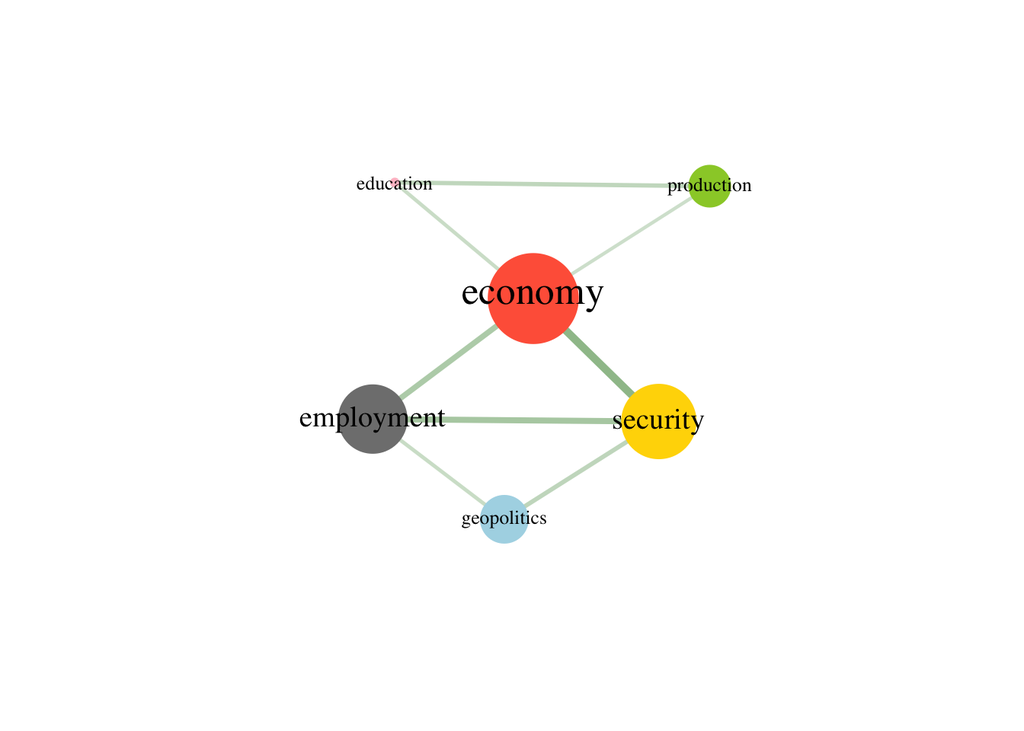

```r
cormatrix<-cor(bycatlist,y=bycatlist,use="all.obs")
#remove the weak/negative correlation
cormatrix[cormatrix<=0.2]<-0
# build a graph from the above matrix
g <- graph.adjacency(cormatrix, weighted=TRUE, mode = "undirected")

# remove loops
g <- simplify(g)

# set labels and degrees of vertices
V(g)$label <- V(g)$name
V(g)$degree <- degree(g)

nodesize<-200*colSums(bycatlist)/sum(bycatlist)

set.seed(1111)
layout1 <- layout.fruchterman.reingold(g)

V(g)$size<-nodesize
V(g)$color<-c("tomato","gray50","gold","yellowgreen","lightblue","pink")
V(g)$label.cex <-0.4*V(g)$degree
V(g)$label.color <- "black"
V(g)$frame.color <- NA
egam <- E(g)$weight
E(g)$color <- rgb(.15, .5, 0.1, egam)
E(g)$width <- 10*egam
 # plot the graph in layout1
 plot(g, layout=layout1)
```

The graph shows that there’s strong cooccurence among economy, employment and national security, which does make sense.The bigger the node/label, the more frequently that topic is mentioned. The wider/darker the edge, the higer correlation exists between those two topics.

## Step 6: Similarity analysis

I calculated the cosine similarity of Trump and Hillary with other presidents seperately. For Hillary, the results coincides with the fact that her political plan is kind of similar with Obama.

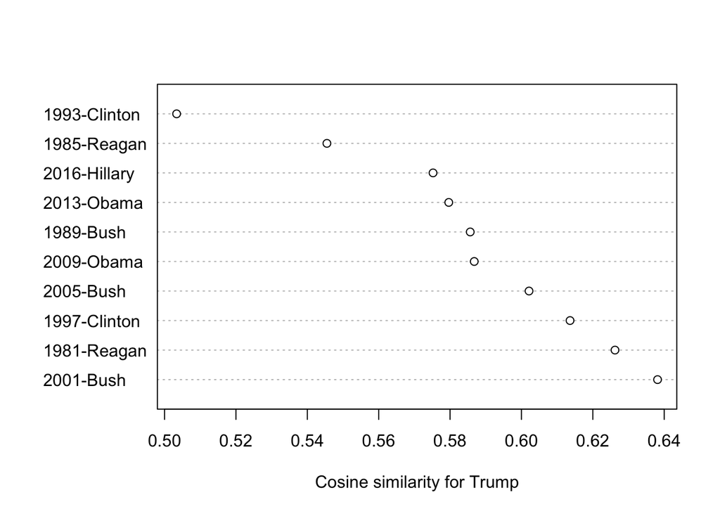

```r
presDfm <- dfm(corpus_subset(presi, Year>1980)+hillary,
               remove = stopwords("english"),
               stem = TRUE, removePunct = TRUE)
trumpSimil <- textstat_simil(presDfm, c("2017-Trump","2016-Hillary"), n = NULL,
                             margin = "documents", method = "cosine")

print(dotchart(as.list(trumpSimil)$"2017-Trump", xlab = "Cosine similarity for Trump"))
```

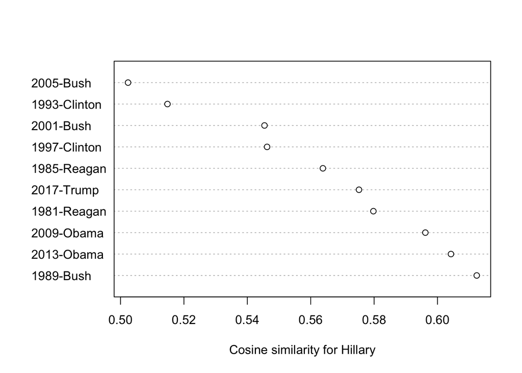

```r
print(dotchart(as.list(trumpSimil)$"2016-Hillary", xlab = "Cosine similarity for Hillary"))
```

## Step 7: k-mean clustering

Here we combine the topic frequency vector and sentimental frequency vector together. In this way, for each president, we get a 14 dimensional vector.

```r
totalcomb<-dfm(cbind(bycat,bysent))
head(totalcomb)
```

```
## Document-feature matrix of: 25 documents, 14 features (0% sparse).
## (showing first 6 documents and first 6 features)
##                 features
## docs             economy employment security production geopolitics
##   1921-Harding        14          4       20          3           3
##   1925-Coolidge       27          6       10          9           9
##   1929-Hoover         18          5        8          3           6
##   1933-Roosevelt      10          5        7          4           2
##   1937-Roosevelt       2          3        2          3           0
##   1941-Roosevelt       5          0        0          3           0
##                 features
## docs             education
##   1921-Harding           1
##   1925-Coolidge          1
##   1929-Hoover            7
##   1933-Roosevelt         0
##   1937-Roosevelt         1
##   1941-Roosevelt         0
```

We use these vectors to do a k-mean clustering.

```r
#choose the appropriate k

k <- round(sqrt(ndoc(totalcomb)/2))

clusterk <- kmeans(tf(totalcomb, "prop"), k)
split(docnames(totalcomb), clusterk$cluster)
```

```
## $`1`
## [1] "2017-Trump"
##
## $`2`
##  [1] "1921-Harding"   "1933-Roosevelt" "1941-Roosevelt" "1961-Kennedy"
##  [5] "1981-Reagan"    "1985-Reagan"    "1993-Clinton"   "2001-Bush"
##  [9] "2005-Bush"      "2009-Obama"     "2013-Obama"
##
## $`3`
## [1] "1945-Roosevelt" "1965-Johnson"   "1989-Bush"      "1997-Clinton"
##
## $`4`
## [1] "1925-Coolidge"   "1929-Hoover"     "1937-Roosevelt"  "1949-Truman"
## [5] "1953-Eisenhower" "1957-Eisenhower" "1969-Nixon"      "1973-Nixon"
## [9] "1977-Carter"
```

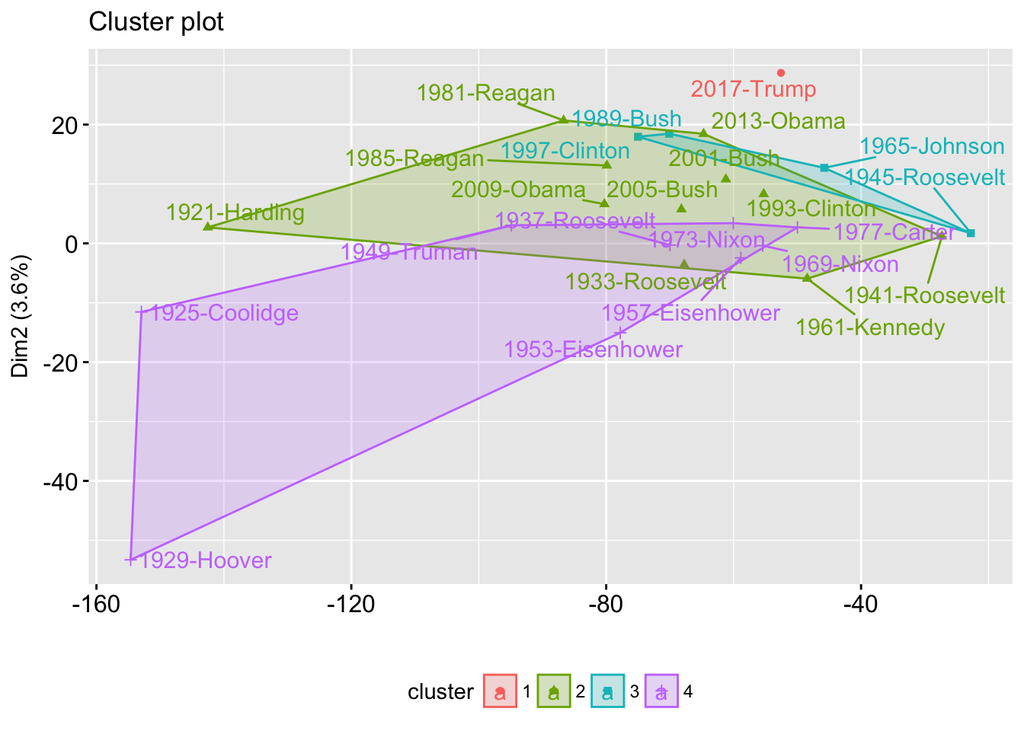

```r
totalcomb<-data.frame(totalcomb)

fviz_cluster(clusterk,
             stand=F, repel= TRUE,data=totalcomb,
              xlab="", xaxt="n",
             show.clust.cent=FALSE)
```

The result is surpursing and very interesting. Does this mean that Trump is really different from other presidents? Maybe the answer is yes.